# Employee Insights

#### Using Data Science to Understand your Employees Better

# Introduction

The average employee turn-over in technology is two years. With this, it's a miracle how any company gets anything done at all.

> Maybe if more companies were better at retaining the employees they had, they wouldn't constantly be chanting WE ARE HIRING!

> — DHH (@dhh) [July 26, 2017](https://twitter.com/dhh/status/890350022881050630?ref_src=twsrc%5Etfw)

How happy and productive your employees has a direct co-relation with the success of your company. So why leave things to chance? Here's how we can use data science to help understand what makes your employees tick, so you can nip problems in the bud!

### In this sample project, we'll use a dummy data-set that contains employee details and other demographics. We'll use data science techniques to get lots of insights, and finally try and see if we can predict whether an employee is likely to call it quits.

## We'll use some of these Python libraries

- [numpy](http://www.numpy.org/) is a package in python that is used for scientific computing. It supports higher-order mathematical functions, higher dimensional arrays, matrices and other data structures.
- [pandas](https://pandas.pydata.org/) is a very popular library that is used for a lot of data analysis and statistics related problems.
- [time](https://docs.python.org/3.7/library/time.html) - standard module in python that allows for time related functions
- display is a module in the IPython toolkit that helps you display data structures in a nice, readable format.
- [matplotlib](https://matplotlib.org/) is a very popular visualization library that lets you create a wide array of figures, charts and graphs in the IPython Notebook
- [seaborn](https://seaborn.pydata.org/index.html) is another visualization tool that uses matplotlib underneath, and provides you with easy-to-use APIs for visualization. It also makes your graphs more prettier!

```python
import pandas as pd
import io
import requests
import matplotlib.pyplot as plt
import matplotlib as matplot
import seaborn as sns
%matplotlib inline
sns.set()
```

# Fetching the data

This will load our dummy data-set

```python
# Fetch the data
data = pd.read_csv("HR_comma_sep.csv", sep=',')

# Display few elements of the data.
#data.head()


# Display the first 10 records
display(data.head(n=10))
```

|  | satisfaction_level | last_evaluation | number_project | average_montly_hours | time_spend_company | Work_accident | left | promotion_last_5years | sales | salary |
| --- | --- | --- | --- | --- | --- | --- | --- | --- | --- | --- |
| 0 | 0.38 | 0.53 | 2 | 157 | 3 | 0 | 1 | 0 | sales | low |
| 1 | 0.80 | 0.86 | 5 | 262 | 6 | 0 | 1 | 0 | sales | medium |
| 2 | 0.11 | 0.88 | 7 | 272 | 4 | 0 | 1 | 0 | sales | medium |
| 3 | 0.72 | 0.87 | 5 | 223 | 5 | 0 | 1 | 0 | sales | low |
| 4 | 0.37 | 0.52 | 2 | 159 | 3 | 0 | 1 | 0 | sales | low |
| 5 | 0.41 | 0.50 | 2 | 153 | 3 | 0 | 1 | 0 | sales | low |
| 6 | 0.10 | 0.77 | 6 | 247 | 4 | 0 | 1 | 0 | sales | low |
| 7 | 0.92 | 0.85 | 5 | 259 | 5 | 0 | 1 | 0 | sales | low |
| 8 | 0.89 | 1.00 | 5 | 224 | 5 | 0 | 1 | 0 | sales | low |
| 9 | 0.42 | 0.53 | 2 | 142 | 3 | 0 | 1 | 0 | sales | low |

## Cleaning the data

### Let's see if any data is null

```python
data.isnull().any()
```

```
satisfaction_level       False
last_evaluation          False
number_project           False
average_montly_hours     False
time_spend_company       False
Work_accident            False
left                     False
promotion_last_5years    False
sales                    False
salary                   False
dtype: bool
```

### Lets see if any data is missing

```python
data.info()
```

```
<class 'pandas.core.frame.DataFrame'>
RangeIndex: 14999 entries, 0 to 14998
Data columns (total 10 columns):
satisfaction_level       14999 non-null float64
last_evaluation          14999 non-null float64
number_project           14999 non-null int64
average_montly_hours     14999 non-null int64
time_spend_company       14999 non-null int64
Work_accident            14999 non-null int64
left                     14999 non-null int64
promotion_last_5years    14999 non-null int64
sales                    14999 non-null object
salary                   14999 non-null object
dtypes: float64(2), int64(6), object(2)
memory usage: 1.1+ MB
```

## Data exploration

Lets rename some of the columns to make them sound more intuitive

```python
# Renaming certain columns for better readability
data = data.rename(columns={

                        'number_project': 'total_projects',
                        'time_spend_company': 'years_at_company',
                        'promotion_last_5years': 'promotion',
                        'sales' : 'department',
                        'average_montly_hours': 'average_monthly_hours',
                        'Work_accident': 'work_accident'
                        })
```

#### Let's check the number of records in the data. As you can see, there are 15000 records with a total of 10 features each -

```python
data.shape
```

```
(14999, 10)
```

```python
data.dtypes
```

```
satisfaction_level       float64
last_evaluation          float64
total_projects             int64
average_monthly_hours      int64
years_at_company           int64
work_accident              int64
left                       int64
promotion                  int64
department                object
salary                    object
dtype: object
```

The fields in the dataset include:

1. Employee satisfaction level, scaling 0 to 1
2. Last evaluation, scaling 0 to 1
3. Number of projects
4. Average monthly hours
5. Time spent at the company in years
6. Whether they have had a work accident
7. Whether they have had a promotion in the last 5 years
8. Sales (which actually means job function).
9. Salary — low, medium or high
10. Whether the employee has left. This will be our target label

## Let's checkout the turnover percentage. As you can see, about 24% employees left and the rest 76% stayed

```python
employee_retention_rate = data.left.value_counts() / len(data)
print(employee_retention_rate)
```

```
0    0.761917
1    0.238083
Name: left, dtype: float64
```

### Let's do a summary of aggregated data for people who stayed and those who left and see if it reveals anything.

```python
summary = data.groupby('left')
summary.mean()
```

| left | satisfaction_level | last_evaluation | total_projects | average_monthly_hours | years_at_company | work_accident | promotion |
| --- | --- | --- | --- | --- | --- | --- | --- |
| 0 | 0.666810 | 0.715473 | 3.786664 | 199.060203 | 3.380032 | 0.175009 | 0.026251 |
| 1 | 0.440098 | 0.718113 | 3.855503 | 207.419210 | 3.876505 | 0.047326 | 0.005321 |

### Insights

> - The mean satisfaction for employees who left is low.
> - The last evaluation score mean for both categorie of employee are very close. This sort-of tells us that there's a high chance of lot of highly evaluated employees leaving, or poorly evaluated employees are being retained.
> - The average working hours mean too is close to each other, this suggest that there's more to just than rigorous working hours for employee turnouts.
> - But the promotion mean is 4 times more for the employees who stayed. This also might mean that people who get promoted are less likely to leave the company and this could be a strategy to retain your best employees.

### Let's get some more statistical summary on the data

```python
data.describe()
```

|  | satisfaction_level | last_evaluation | total_projects | average_monthly_hours | years_at_company | work_accident | left | promotion |
| --- | --- | --- | --- | --- | --- | --- | --- | --- |
| count | 14999.000000 | 14999.000000 | 14999.000000 | 14999.000000 | 14999.000000 | 14999.000000 | 14999.000000 | 14999.000000 |
| mean | 0.612834 | 0.716102 | 3.803054 | 201.050337 | 3.498233 | 0.144610 | 0.238083 | 0.021268 |
| std | 0.248631 | 0.171169 | 1.232592 | 49.943099 | 1.460136 | 0.351719 | 0.425924 | 0.144281 |
| min | 0.090000 | 0.360000 | 2.000000 | 96.000000 | 2.000000 | 0.000000 | 0.000000 | 0.000000 |
| 25% | 0.440000 | 0.560000 | 3.000000 | 156.000000 | 3.000000 | 0.000000 | 0.000000 | 0.000000 |
| 50% | 0.640000 | 0.720000 | 4.000000 | 200.000000 | 3.000000 | 0.000000 | 0.000000 | 0.000000 |
| 75% | 0.820000 | 0.870000 | 5.000000 | 245.000000 | 4.000000 | 0.000000 | 0.000000 | 0.000000 |
| max | 1.000000 | 1.000000 | 7.000000 | 310.000000 | 10.000000 | 1.000000 | 1.000000 | 1.000000 |

# Data Visualization

#### Using this, we'll be able visualize our data better and also observe some co-relations between different features, which might have previously gone unnoticed.

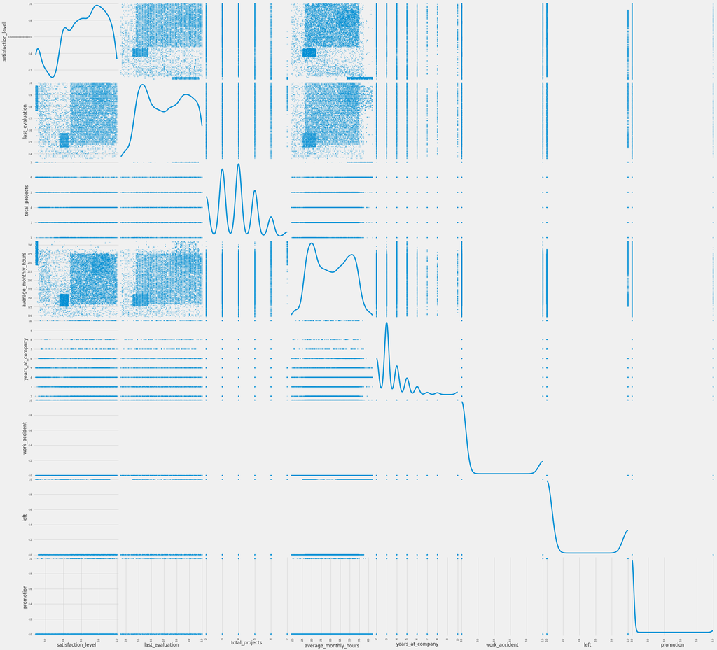

```python
pd.plotting.scatter_matrix(data, alpha = 0.3, figsize = (40,40), diagonal = 'kde');
```

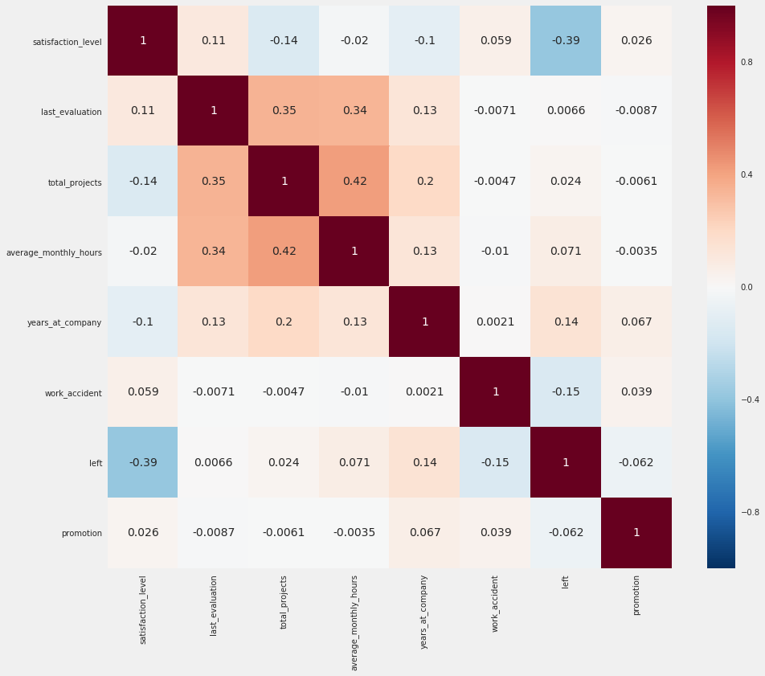

```python
correlation = data.corr()
#display(correlation)
plt.figure(figsize=(14, 12))
heatmap = sns.heatmap(correlation, annot=True, linewidths=0, vmin=-1, cmap="RdBu_r")
```

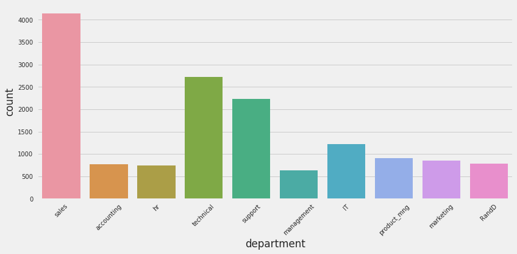

```python
fig, axs = plt.subplots(ncols=1,figsize=(12,6))
g = sns.countplot(data["department"], ax=axs)
plt.setp(g.get_xticklabels(), rotation=45)
plt.tight_layout()
plt.show()
plt.gcf().clear()
```

### Insight: The sales team followed by technical and support consitutes the major chunk of the employees.

### Plot of no.of.employees within the three salary range

- Most of the employees fall in medium or least salary range.

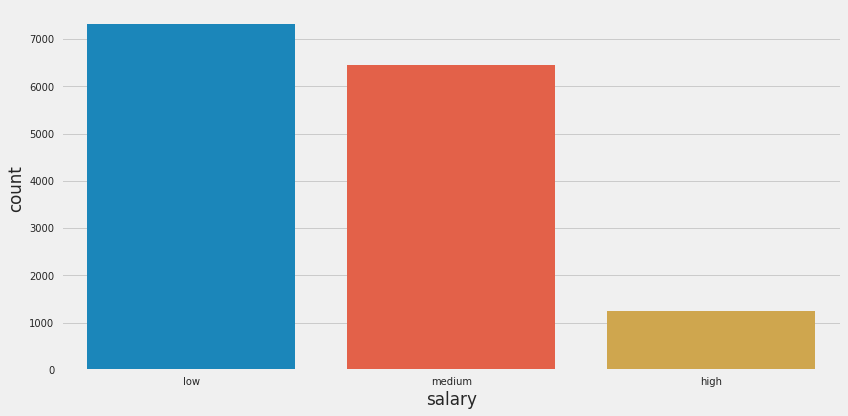

```python
fig, axs = plt.subplots(ncols=1,figsize=(12,6))
g = sns.countplot(data["salary"], ax=axs)
plt.tight_layout()
plt.show()
plt.gcf().clear()
```

# Turnover vs other features

### In our quest to find the most contributing features for the employee turnover, let's find the co-relation between `turnover` and other features and then plot them to see whether there's a clear trend.

### Turnover vs Experience

```
Text(0.5,1,'Turnover VS experience')
```

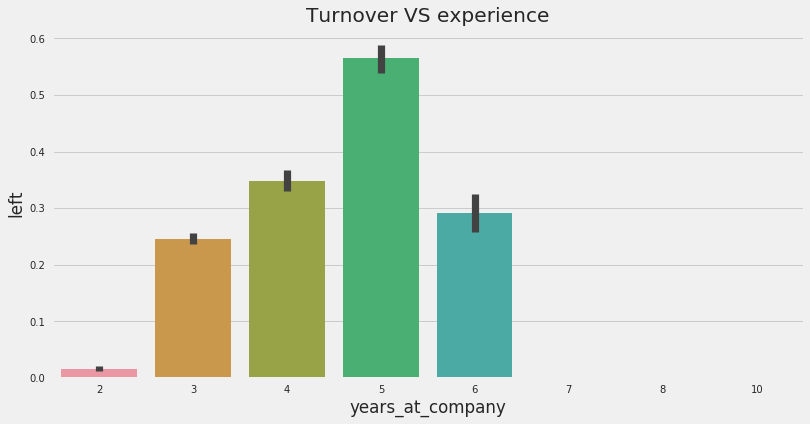

```python
sns.barplot(x = 'years_at_company', y = 'left', data = data)
plt.title('Turnover VS experience')
```

### Insight: We see that the employees between 4-6 years experience tend to leave the company.

### Turnover VS Number of projects

```
Text(0.5,1,'Number of projects VS Turnover')
```

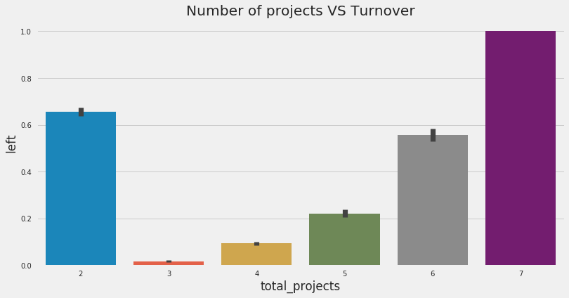

```python
sns.barplot(x = 'total_projects', y = 'left', data = data)
plt.title('Number of projects VS Turnover')
```

### Insights:

> - It's very clear that employees with less number of projects or the ones with too many projects leave the company.
> - This suggests the employees who are under worked and who are overworked tend to leave the company.
> - Just with this plot we can clearly see that the total number projects is an very important factor towards employee turn-over.
> - What's interesting is that there is 100% turn over w.r.t the employees with 7 projects.

### Turnover Vs Last evaluation

- The graphs show a clear trend, ones with poor or great last_evaluation tend to leave the company.

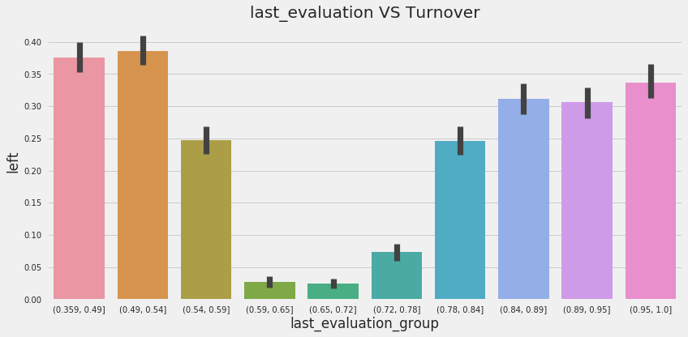

```python
fig, axs = plt.subplots(ncols=1,figsize=(12,6))
data['last_evaluation_group'] = pd.qcut(data['last_evaluation'], 10)
sns.barplot(x='last_evaluation_group', y='left', data=data)
plt.title('last_evaluation VS Turnover')

plt.tight_layout()
plt.show()
plt.gcf().clear()
```

### Turnover vs Satisfaction

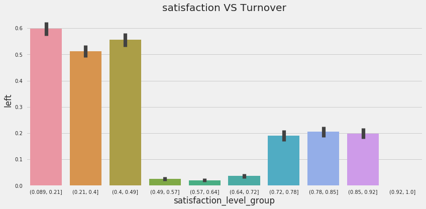

```python
fig, axs = plt.subplots(ncols=1,figsize=(12,6))
data['satisfaction_level_group'] = pd.qcut(data['satisfaction_level'], 10)
sns.barplot(x='satisfaction_level_group', y='left', data=data)
plt.title('satisfaction VS Turnover')

plt.tight_layout()
plt.show()
plt.gcf().clear()
```

# Feature selection

Firstly we need to identify the most important features for employee turnover. We'll be the some of the classifiers in the next section not for training purposes, but just for understanding which are the most important features that influence employee turnover. Here are the techniques we'll be using for feature selection -

- Co-relation heatmap
- Random Forest Classifier
- XGBoost Classifier
- Decision Trees (they reveal much more than that top features)

## Preparing the data for training

```python
from sklearn.metrics import fbeta_score
from sklearn.metrics import accuracy_score

from sklearn.model_selection import train_test_split
import numpy as np
plt.style.use('fivethirtyeight')
plt.rcParams['figure.figsize'] = (12,6)

df = data.drop(['last_evaluation_group','satisfaction_level_group'],axis=1)

# Convert these variables into categorical variables.
df["department"] = df["department"].astype('category').cat.codes
df["salary"] = df["salary"].astype('category').cat.codes

# Display the first 10 records
display(df.head(n=10))

# Create train and test splits
target_name = 'left'
X = df.drop('left', axis=1)

# obtain the target value. Its the employee turnover.
y = df[target_name]
# Split the data into test and training set.
X_train, X_test, y_train, y_test = train_test_split(X,y,test_size=0.15, random_state=123, stratify=y)
```

|  | satisfaction_level | last_evaluation | total_projects | average_monthly_hours | years_at_company | work_accident | left | promotion | department | salary |
| --- | --- | --- | --- | --- | --- | --- | --- | --- | --- | --- |
| 0 | 0.38 | 0.53 | 2 | 157 | 3 | 0 | 1 | 0 | 7 | 1 |
| 1 | 0.80 | 0.86 | 5 | 262 | 6 | 0 | 1 | 0 | 7 | 2 |
| 2 | 0.11 | 0.88 | 7 | 272 | 4 | 0 | 1 | 0 | 7 | 2 |
| 3 | 0.72 | 0.87 | 5 | 223 | 5 | 0 | 1 | 0 | 7 | 1 |
| 4 | 0.37 | 0.52 | 2 | 159 | 3 | 0 | 1 | 0 | 7 | 1 |
| 5 | 0.41 | 0.50 | 2 | 153 | 3 | 0 | 1 | 0 | 7 | 1 |
| 6 | 0.10 | 0.77 | 6 | 247 | 4 | 0 | 1 | 0 | 7 | 1 |
| 7 | 0.92 | 0.85 | 5 | 259 | 5 | 0 | 1 | 0 | 7 | 1 |
| 8 | 0.89 | 1.00 | 5 | 224 | 5 | 0 | 1 | 0 | 7 | 1 |
| 9 | 0.42 | 0.53 | 2 | 142 | 3 | 0 | 1 | 0 | 7 | 1 |

### Random Forest Classifier for feature selection

```python
from sklearn.ensemble import RandomForestClassifier
from sklearn.model_selection import GridSearchCV, cross_val_score, learning_curve

RFC = RandomForestClassifier()

RFC.fit(X_train,y_train)

rfc_predictions_train = RFC.predict(X_train)
rfc_predictions_test = RFC.predict(X_test)

rfc_training_accuracy_score = accuracy_score(y_train, rfc_predictions_train)
rfc_test_accuracy_score = accuracy_score(y_test, rfc_predictions_test)
print("Random Forest accuracy on training set:",rfc_training_accuracy_score)
print("Random Forest accuracy on testing set:",rfc_test_accuracy_score)

rfc_training_fbeta_score = fbeta_score(y_train, rfc_predictions_train, beta=0.5, average='micro')
rfc_test_fbeta_score = fbeta_score(y_test, rfc_predictions_test, beta=0.5, average='micro')
print("Random Forest fbeta score on training set:",rfc_training_fbeta_score)
print("Random Forest fbeta score on testing set:",rfc_test_fbeta_score)
```

```
Random Forest accuracy on training set: 0.9984312495097655
Random Forest accuracy on testing set: 0.9924444444444445
Random Forest fbeta score on training set: 0.9984312495097655
Random Forest fbeta score on testing set: 0.9924444444444446
```

```
Index(['satisfaction_level', 'last_evaluation', 'total_projects',
       'average_monthly_hours', 'years_at_company', 'work_accident',
       'promotion', 'department', 'salary'],
      dtype='object')
[0 4 2 3 1 7 8 5 6]
```

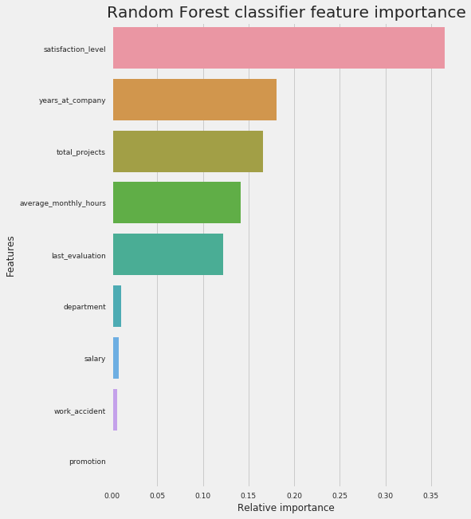

```python
indices = np.argsort(RFC.feature_importances_)[::-1]

train_features = X_train.columns

print(train_features)
print(indices)

fig = plt.figure(figsize=(7, 10))
g = sns.barplot(y=train_features[indices],x = RFC.feature_importances_[indices] , orient='h')
g.set_xlabel("Relative importance",fontsize=12)
g.set_ylabel("Features",fontsize=12)
g.tick_params(labelsize=9)
g.set_title("Random Forest classifier feature importance")

plt.show()
plt.gcf().clear()
```

## XGBoost classifier for feature selection

```
You are using pip version 10.0.1, however version 18.1 is available.
```

```
XGBoost accuracy on training set: 0.9774099929406228
XGBoost accuracy on testing set: 0.9715555555555555
XGBoost fbeta score on training set: 0.9774099929406228
XGBoost fbeta score on testing set: 0.9715555555555555
[0.2394636  0.16666667 0.15134099 0.18965517 0.17049809 0.02873563
 0.         0.0210728  0.03256705]
[0 3 4 1 2 8 5 7 6]
Index(['satisfaction_level', 'last_evaluation', 'total_projects',
       'average_monthly_hours', 'years_at_company', 'work_accident',
       'promotion', 'department', 'salary'],
      dtype='object')
[0 3 4 1 2 8 5 7 6]
```

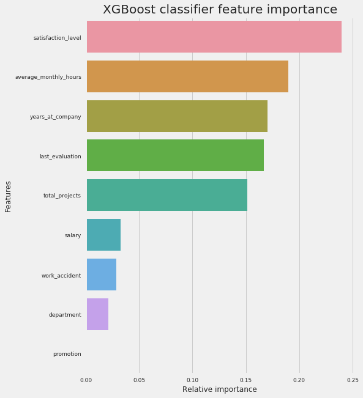

```python
!pip install xgboost
from xgboost import XGBClassifier

model = XGBClassifier()
model.fit(X_train, y_train)

xgb_predictions_train = model.predict(X_train)
xgb_predictions_test = model.predict(X_test)

xgb_training_accuracy_score = accuracy_score(y_train, xgb_predictions_train)
xgb_test_accuracy_score = accuracy_score(y_test, xgb_predictions_test)
print("XGBoost accuracy on training set:",xgb_training_accuracy_score)
print("XGBoost accuracy on testing set:",xgb_test_accuracy_score)

xgb_training_fbeta_score = fbeta_score(y_train, xgb_predictions_train, beta=0.5, average='micro')
xgb_test_fbeta_score = fbeta_score(y_test, xgb_predictions_test, beta=0.5, average='micro')
print("XGBoost fbeta score on training set:",xgb_training_fbeta_score)
print("XGBoost fbeta score on testing set:",xgb_test_fbeta_score)
# feature importance
print(model.feature_importances_)

indices = np.argsort(model.feature_importances_)[::-1]

print(indices)

train_features = X_train.columns

print(train_features)
print(indices)

fig = plt.figure(figsize=(7, 10))
g = sns.barplot(y=train_features[indices],x = model.feature_importances_[indices] , orient='h')
g.set_xlabel("Relative importance",fontsize=12)
g.set_ylabel("Features",fontsize=12)
g.tick_params(labelsize=9)
g.set_title("XGBoost classifier feature importance")

plt.show()
plt.gcf().clear()
```

## Decision Tree Classifier

Now that we know the most important features let's run the DT classifier with depth of 3 and visualize the tree which will answer some very critical questions -

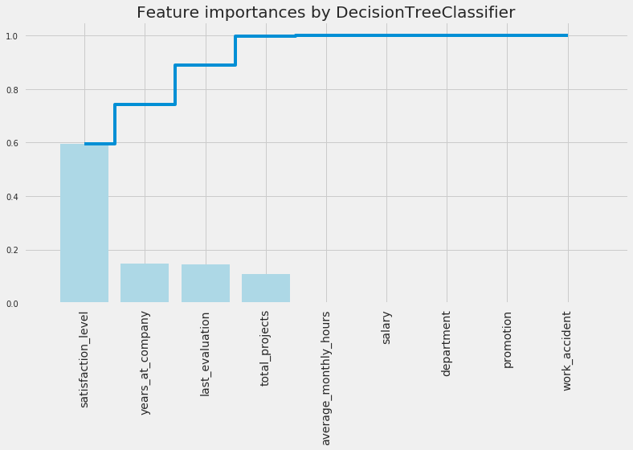

[output not shown]

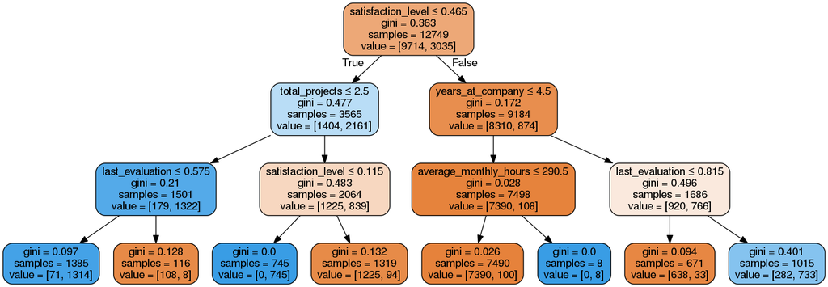

```python
#from sklearn import tree
from sklearn.tree import DecisionTreeClassifier

dtree = DecisionTreeClassifier(max_depth=3)
dtree = dtree.fit(X_train,y_train)

## plot the importances ##
importances = dtree.feature_importances_
feat_names = df.drop(['left'],axis=1).columns


indices = np.argsort(importances)[::-1]
plt.figure(figsize=(12,6))
plt.title("Feature importances by DecisionTreeClassifier")
plt.bar(range(len(indices)), importances[indices], color='lightblue',  align="center")
plt.step(range(len(indices)), np.cumsum(importances[indices]), where='mid', label='Cumulative')
plt.xticks(range(len(indices)), feat_names[indices], rotation='vertical',fontsize=14)
plt.xlim([-1, len(indices)])
plt.show()

!pip install graphviz
!apt-get install -y graphviz
!pip install pydotplus

from sklearn.tree import export_graphviz
import graphviz
from sklearn.externals.six import StringIO
from IPython.display import Image
import pydotplus

dot_data = StringIO()

export_graphviz(dtree, out_file=dot_data,
                filled=True, rounded=True,
                special_characters=True,feature_names=X_train.columns)

graph = pydotplus.graph_from_dot_data(dot_data.getvalue())

graph.set_lwidth(100)
graph.set_lheight(100)
Image(graph.create_png())

#export_graphviz(dtree, out_file="mytree.dot")
#with open("mytree.dot") as f:
#    dot_graph = f.read()
#graphviz.Source(dot_graph)
```

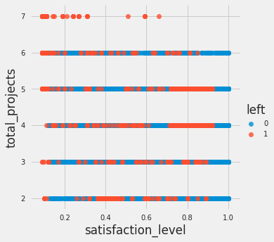

```python
sns.lmplot(x='satisfaction_level', y='total_projects', data=df,
           fit_reg=False, # No regression line
           hue='left')
```

```python
data_stay = df[df["left"]==0]
data_left = df[df["left"]==1]
```

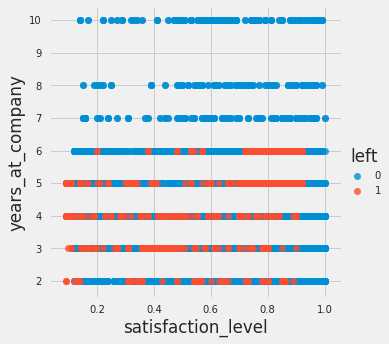

```python
sns.lmplot(x='satisfaction_level', y='years_at_company', data=df,
           fit_reg=False, # No regression line
           hue='left')
```

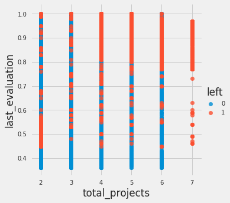

```python
sns.lmplot(x='total_projects', y='last_evaluation', data=df,
           fit_reg=False, # No regression line
           hue='left')
```

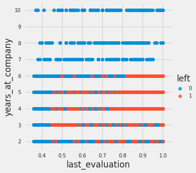

```python
sns.lmplot(x='last_evaluation', y='years_at_company', data=df,
           fit_reg=False, # No regression line
           hue='left')
```

We clearly see 3 red clusters in the visualization of `satisfaction vs evaluation` (see below). We can separate these clusters out using K-means clustering with 3 clusters and then analyze these groups. On analysis, we see some interesting patterns emerge -

- **Performing but unsatisfied:** The left most red cluster corresponds to employees who performed well but were really unsatisfied and left the company. Why is this happening? The company is supposed to maintain the interests of well performing employees.
- **Not performing Not satisfied:** The middle red cluster corresponds to employees who are not performing well and not happy too and they've left the company.
- **Performing and satisfied:** Here is the most alarming cluster, the right-most red cluster on the top. These are well performing and satisfied employees who have left the company. It would very interesting to know why.

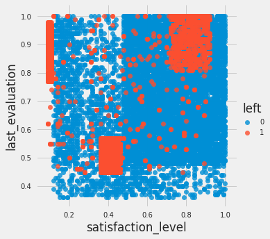

```python
sns.lmplot(x='satisfaction_level', y='last_evaluation', data=df,
           fit_reg=False, # No regression line
           hue='left')
```

## K-Means clustering

Let's use K-means clustering on the data of people who left the company. Since we saw a clear grouping in employees who left the company in the `satisfaction vs evaluation` scatter plot, let's use these features to separate out the clusters and perform further analysis on each one of them.

```python
from sklearn.cluster import KMeans

# Obtain the data for the employees who've left the company.
data_left = df[df["left"]==1]

data_stayed = df[df["left"]==0]

print(data_left.shape)

kmeans = KMeans(n_clusters=3,random_state=2)
kmeans.fit(data_left[["satisfaction_level","last_evaluation"]])
```

```
(3571, 10)
```

```
KMeans(algorithm='auto', copy_x=True, init='k-means++', max_iter=300,
    n_clusters=3, n_init=10, n_jobs=1, precompute_distances='auto',
    random_state=2, tol=0.0001, verbose=0)
```

```
cluster center 1:  (0.8085158648925284, 0.9117093142272266)
cluster center 2:  (0.4101454545454546, 0.5169818181818187)
cluster center 3:  (0.11115466101694843, 0.8693008474576276)
```

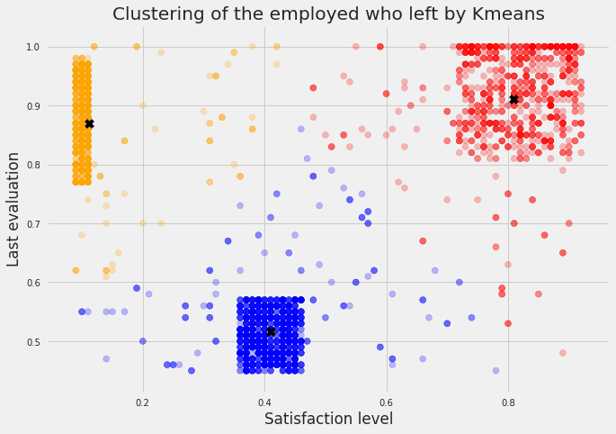

```python
kmeans_colors = ['red' if c == 0 else 'orange' if c == 2 else 'blue' for c in kmeans.labels_]

fig = plt.figure(figsize=(10, 7))
plt.scatter(x="satisfaction_level",y="last_evaluation", data=data_left,
            alpha=0.25,color = kmeans_colors)
plt.xlabel("Satisfaction level")
plt.ylabel("Last evaluation")

clusters_center_x = kmeans.cluster_centers_[:,0]
clusters_center_y = kmeans.cluster_centers_[:,1]

print('cluster center 1: ', (clusters_center_x[0], clusters_center_y[0]))
print('cluster center 2: ', (clusters_center_x[1], clusters_center_y[1]))
print('cluster center 3: ', (clusters_center_x[2], clusters_center_y[2]))
plt.scatter(x = clusters_center_x, y = clusters_center_y, color="black",marker="X",s=100)
plt.title("Clustering of the employed who left by Kmeans")

plt.show()
```

Again, here are the 3 groups from the clusters.

- **Performing Unhappy**: Successful but unhappy employees. This is the yellow group on the top left
- **Performing Happy**: Successful and happy employees. These constitute the red group on the top right
- **Non-performing Unhappy**: Unsuccessful and unhappy employees. This is the blue group on the bottom

```python
performing_satisfied_left = data_left[kmeans.labels_ == 0]
nonperforming_unsatisfied_left = data_left[kmeans.labels_ == 1]
performing_unsatisfied_left = data_left[kmeans.labels_ == 2]

print("Employees left: ")
print("Performing Happy: ",performing_satisfied_left.shape)
print("Non-performing Unhappy: ",nonperforming_unsatisfied_left.shape)
print("Performing UnHappy: ",performing_unsatisfied_left.shape)
```

```
Employees left:
Performing Happy:  (977, 10)
Non-performing Unhappy:  (1650, 10)
Performing UnHappy:  (944, 10)
```

## Insight:

> It's disastrous to see that 977 of well performing and happy employees left and 944 of well performing employees who were unhappy left the company.

### A Radar Chart on average features of employees who stayed and employees who left, from each of the three clusters, should help us find the most important factors for employee turnover.

> Note to self: Couldn't find a library to draw the radar chart, so I just used an implementation that I found online.

```python
# Code to draw Radar chart.
def _scale_data(data, ranges):
    (x1, x2) = ranges[0]
    d = data[0]
    return [(d - y1) / (y2 - y1) * (x2 - x1) + x1 for d, (y1, y2) in zip(data, ranges)]


class RadarChart():
    def __init__(self, fig, variables, ranges, n_ordinate_levels = 6):
        angles = np.arange(0, 360, 360./len(variables))

        axes = [fig.add_axes([0.1,0.1,0.8,0.8],polar = True,
        label = "axes{}".format(i)) for i in range(len(variables))]
        _, text = axes[0].set_thetagrids(angles, labels = variables)

        for txt, angle in zip(text, angles):
            txt.set_rotation(angle - 90)

        for ax in axes[1:]:
            ax.patch.set_visible(False)
            ax.xaxis.set_visible(False)
            ax.grid("off")

        for i, ax in enumerate(axes):
            grid = np.linspace(*ranges[i],num = n_ordinate_levels)
            grid_label = [""]+["{:.1f}".format(x) for x in grid[1:]]
            ax.set_rgrids(grid, labels = grid_label, angle = angles[i])
            ax.set_ylim(*ranges[i])

        self.angle = np.deg2rad(np.r_[angles, angles[0]])
        self.ranges = ranges
        self.ax = axes[0]

    def plot(self, data, *args, **kw):
        sdata = _scale_data(data, self.ranges)
        self.ax.plot(self.angle, np.r_[sdata, sdata[0]], *args, **kw)

    def fill(self, data, *args, **kw):
        sdata = _scale_data(data, self.ranges)
        self.ax.fill(self.angle, np.r_[sdata, sdata[0]], *args, **kw)

    def legend(self, *args, **kw):
        self.ax.legend(*args, **kw)
```

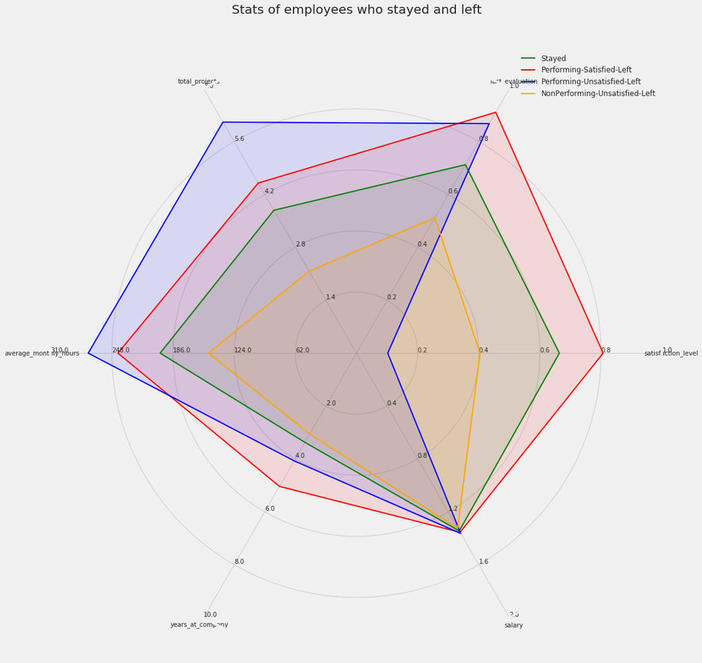

```python
df["salary"] = df["salary"].astype('category').cat.codes
data_stayed["salary"] = data_stayed["salary"].astype('category').cat.codes
performing_unsatisfied_left["salary"] = performing_unsatisfied_left["salary"].astype('category').cat.codes
performing_satisfied_left["salary"] = performing_satisfied_left["salary"].astype('category').cat.codes
nonperforming_unsatisfied_left["salary"] = nonperforming_unsatisfied_left["salary"].astype('category').cat.codes




attributes = ['satisfaction_level','last_evaluation','total_projects','average_monthly_hours','years_at_company','salary']
ranges = [[1e-2, df[attr].max()] for attr in attributes]


fig = plt.figure(figsize=(8, 8))



stayed_mean = data_stayed[attributes].mean().values.reshape(1,-1)
performing_unsatisfied_left_mean = performing_unsatisfied_left[attributes].mean().values.reshape(1,-1)
performing_satisfied_left_mean = performing_satisfied_left[attributes].mean().values.reshape(1,-1)
nonPerforming_unsatisfied_left_mean = nonperforming_unsatisfied_left[attributes].mean().values.reshape(1,-1)


radar_data = np.concatenate((np.array(stayed_mean), np.array(performing_satisfied_left_mean),
                      np.array(performing_unsatisfied_left_mean), np.array(nonPerforming_unsatisfied_left_mean)),axis=0)


colors = ["green","red","blue","orange"]
left_types = ["Stayed","Performing-Satisfied-Left", "Performing-Unsatisfied-Left", "NonPerforming-Unsatisfied-Left"]

fig = plt.figure(figsize=(17, 17))
radar = RadarChart(fig, attributes, ranges)
for data, color, left_type in zip(radar_data, colors, left_types):
    radar.plot(np.array(data), color = color, label = left_type, linewidth=2.0)
    radar.fill(data, alpha = 0.1, color = color)
    radar.legend(loc = 1, fontsize = 'small')
plt.title('Stats of employees who stayed and left')

plt.show()
```

# Radar Graph interpretation

## Insights:

> - The radar graph shows that the mean salary is the same for all cluster of employees. This clearly tells that the well performing employees need a raise.
> - It's clear why a large section of well performing employees are unsatisfied and they leave the company. The blue part in the radar graph indicates that these employees work way too many projects and thus spend far too many hours at office but still get paid the same like the others. Pretty soon they become unsatisfied. It's clear that they might under lot of stress at work and their load has to reduce to improve the chances of retaining them.
> - As you can see in the red, highly performing and satisfied employee who leave the company tend to spend more number of hours at office on few projects, and they also tend to stay longer in the company.

## Now, can you predict an employee leaving the company in advance?

Let's try giving some data to one of our models and see what it tells us

```python
"""Give inputs in this order: satisfaction_level, last_evaluation, total_projects, average_monthly_hours,
years_at_company, work_accident, promotion, department, salary
"""

employee_data = [[0.4, 0.4, 7, 250, 6, 0, 0, 7, 1],
                [0.7, 0.6, 5, 200, 4, 0, 0, 7, 1]
                ]

# Show predictions
for i, prediction in enumerate(RFC.predict(employee_data)):
    print("Employee {} is going to {}.".format(i+1, 'leave' if prediction == 1 else 'stay'))
```

```
Employee 1 is going to leave.
Employee 2 is going to stay.
```

## Insights

# Notes

What we have seen so far all happened in the past, which you cannot undo. However, if you can predict the future, you can do something about it. Making data actionable — that’s the true value of predictive analytics that we do at Hyphen

> *The best companies aren’t families. They’re **supporters** of families. **Allies** of families. There to provide healthy, fulfilling work environments so when workers shut their laptops at a reasonable hour, they’re the best husbands, wives, parents, siblings, and children they can be.* - **David Heinemeier Hansson**, creator of **Ruby on Rails** and **Basecamp**.

### We can't help but agree! And this will what help them be the best employees too.